# Conserved-region clustering, tuned to phastCons

phyloP scores conservation base-by-base. At **Zoonomia (241-mammal) depth** those per-base calls are effectively single-base resolution (see ../phylop-tree-length-power/). Turning them into conserved **elements** is a separate clustering step — and at this depth it is the *same* problem the pipeline's phastCons branch already faces: phastCons's own raw output here is near-per-base (median 2 bp), and only becomes elements after a downstream merge + length filter. So the real question isn't "phyloP vs phastCons," it's **how do you segment per-base conservation calls into elements**, and the natural yardstick is **phastCons**.

This notebook runs four clustering methods on real data, **tunes each to best reproduce phastCons's conserved elements**, and compares the tuned methods (and phastCons) head to head.

**Data:** a 2 Mb slice — `chr1:26,000,000–28,000,000` (human GRCh38) — of the real Zoonomia 241-mammal phyloP output: 170,335 FDR-significant conserved sites, shifted to a 0-based mini-chromosome. No alignment needed for the clustering; the phastCons reference *is* built from the alignment (below).

**Methods** (all take significant-site positions → regions; implemented in `lib/clustering.py`):

| method | what it does |
| --- | --- |
| **windowed** | fixed-size bins; bins with ≥ k sites are conserved; merge adjacent |
| **hmm** | 2-state online HMM over the per-position conserved/not stream (from the legacy script) |
| **hdbscan** | 1-D density clustering of site positions |
| **gap-merge (current)** | the pipeline's existing method: merge sites within a gap, then length-filter |

```python
import lib.clustering as C
sites = [(int(s), int(e)) for _, s, e in
         (ln.split() for ln in open('data/chr1_26-28Mb.conserved-sites.bed'))]
LENGTH = 2_000_000
# each returns [(start, end, n_sites), ...]:
win = C.windowed(sites, LENGTH, window_bp=20, min_sites_per_window=5)
hmm = C.hmm(sites, LENGTH, t1_1=0.99, e1_1=0.5, min_len=20)
hdb = C.hdbscan_cluster(sites, min_cluster_size=5)
# full runs + figures: cluster_compare.py (defaults) and concordance.py (tuning + phastCons)
```

## Why tuning is required first

At out-of-the-box parameters the four methods span a **~18× range in coverage** — from 2% to 42% of the slice — which is almost entirely an artifact of arbitrary defaults, not method quality:

| method | coverage (default) | regions |
| --- | --- | --- |
| hmm | **2.4%** | 1,022 |
| gap-merge (current) | 22.9% | 3,989 |
| windowed | 23.1% | 2,780 |
| hdbscan | **42.0%** | 2,802 |

You can't rank methods that are set to call wildly different amounts of sequence. So we first **fix each method's parameters against a common target** — phastCons — and only then compare. (Full default-parameter metrics and figures: `cluster_compare.py` → `cluster_metrics.csv`.)

## Tuning to phastCons

**Building the reference (and a caveat we had to fix).** phastCons was run on the real 241-species alignment of chr1:26–28 Mb (extracted from the 557 GB chromosome MAF) with the run's neutral model. Its raw `--most-conserved` output is *near per-base* — 101k fragments, **median 2 bp** — because the pipeline's `--rho`-only invocation sets no expected element length **and** this region of the 241-way alignment is thousands of tiny blocks with unaligned gaps, so phastCons never sustains long runs (even `--expected-length 45` only reached median 5 bp). The pipeline never uses that raw output as elements — it **merges fragments within `cnee_ces_merge_gap_bp` (5 bp) and drops anything under `cnee_min_len_bp` (50 bp)**. Doing exactly that yields a sensible element set — **1,254 elements, median 101 bp, 9.1% coverage** (≈ Zoonomia's ~10% genome-wide constrained fraction) — which is the reference used here.

**Objective — bp-level F1 vs the phastCons elements.** Two errors a method can make, in base pairs:

- **false positives (FP)** — bp the method calls conserved that are **not** in a phastCons element (over-calls). `precision = TP / (TP + FP)`.
- **false negatives (FN)** — phastCons element bp the method **misses**. `recall = TP / (TP + FN)`.

**F1** combines precision and recall into one score (0–1) that is only high when *both* are — so a method can't win by over-calling (high recall, low precision) or under-calling. For scale, phastCons covers **182 kb (9.1%)** of the 2 Mb slice. We grid-searched each method's parameters to maximize F1; **the HMM stays the simple 2-state model** (we only pick better values for its 5 probabilities).

| method | default → tuned F1 | precision | recall | **false pos** | **false neg** | best params |
| --- | --- | --- | --- | --- | --- | --- |
| **hmm** | 0.42 → **0.85** | 0.84 | 0.86 | **31 kb** | 25 kb | t11=.99, e11=.5, min_len=20 |
| gap-merge (current) | 0.56 → **0.82** | 0.74 | 0.93 | 61 kb | **12 kb** | gap=10, ≥10 sites, len 20 |
| windowed | 0.56 → **0.80** | 0.73 | 0.89 | 61 kb | 20 kb | 20 bp, ≥5 sites |
| hdbscan | 0.34 → **0.35** | 0.22 | 0.88 | **569 kb** | 22 kb | mcs=5 (fair grid: eom/leaf × mcs × min_samples) |

**Read the FP/FN columns across:** every method *misses* little (FN 12–25 kb — they all recover phastCons). The whole difference is **over-calling**: the three good methods add only 30–60 kb of false positives, while **hdbscan adds 569 kb — ~3× phastCons's entire 182 kb footprint** — which is exactly why its precision (0.22) and F1 (0.35) collapse despite fine recall.

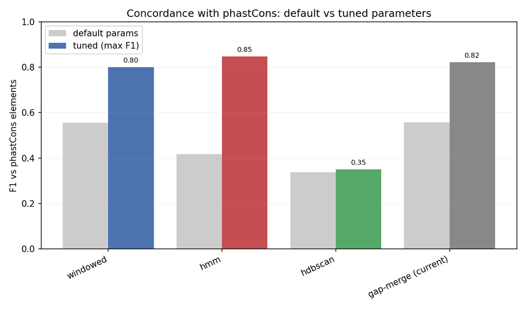

```python
from IPython.display import Image
Image('figures/concordance_f1.png')
```

## The tuned methods, head to head

At their phastCons-tuned settings, the four methods produce very different element sets — and three of them land right where phastCons is:

| method | coverage | regions | median element |
| --- | --- | --- | --- |
| **phastCons (reference)** | 9.1% | 1,254 | 101 bp |
| hmm | 9.4% | 2,081 | 48 bp |
| gap-merge (current) | 11.5% | 1,898 | 75 bp |
| windowed | 11.2% | 2,903 | 20 bp |
| hdbscan | 36.5% | 6,764 | 57 bp |

**Track view** — a 60 kb window: raw significant sites on top, then each tuned element set. hmm, gap-merge, and windowed track phastCons (gold); hdbscan (green) is a wall of over-coverage.

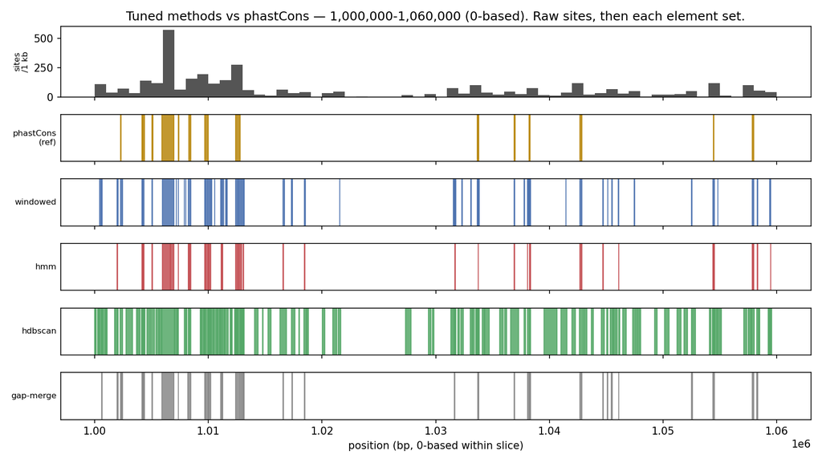

```python
Image('figures/tuned_track.png')
```

**Element-length distributions** (tuned) vs phastCons (dashed). gap-merge sits closest to phastCons's length profile; windowed pins to its 20 bp bin; hdbscan spreads long.

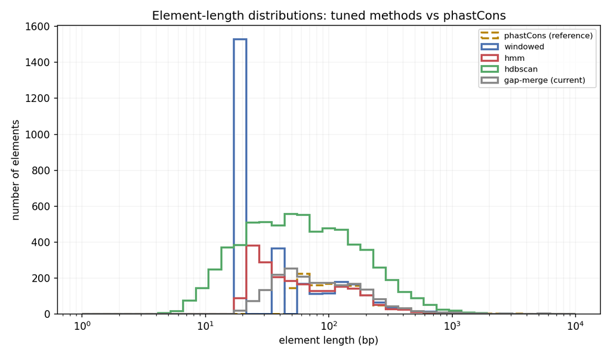

```python
Image('figures/tuned_sizes.png')
```

**Agreement** — Jaccard of the base pairs each tuned method calls conserved. hmm agrees most with phastCons (0.74); gap-merge (0.70) and windowed (0.67) close behind; the three agree with each other ~0.74. hdbscan agrees with nothing (~0.21).

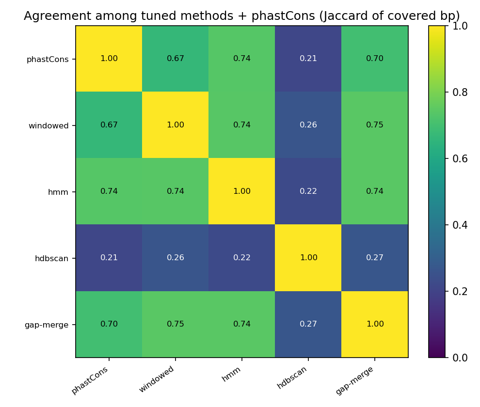

```python
Image('figures/tuned_jaccard.png')
```

## Observations

- **All four methods have low false negatives (12–25 kb).** They *all* recover phastCons's elements — none of them meaningfully *misses* conservation. So the whole comparison comes down to **false positives** (over-calling), which is what the F1 differences track.
- **The simple HMM comes out best (F1 0.85, Jaccard 0.74 with phastCons)** — only **31 kb** of false positives, precision 0.84, recall 0.86 — while staying the fast 2-state model (`t11=0.99, e11=0.5, min_len=20`). A cheap HMM reproduces phastCons's *elements* well; that's its reason for existing.
- **gap-merge and windowed are close** (F1 0.82 / 0.80; ~60 kb false positives). The three coherent-region methods agree with phastCons and each other (mutual Jaccard ~0.74) and land at its ~9–12% coverage.
- **hdbscan fails on false positives (F1 0.35) — and it's not a tuning artifact.** We gave it a fair grid (`eom` *and* `leaf` selection, a range of `min_cluster_size`/`min_samples`); its best is still **569 kb of false positives** (3× phastCons's footprint), precision 0.22. Density clustering links sites across gaps into over-large regions, and no setting we tried fixes it — it's the wrong tool for compact conserved elements.
- **Tuning is decisive.** The HMM went 0.42 → 0.85; the raw default comparison (2% vs 42% coverage) was almost pure parameter artifact.

**Caveats.** One 2 Mb region of one chromosome; a single phastCons setting; bp-level (not element-boundary) matching; parameters tuned on the same region they are scored on. And the F1s are sensitive to how the phastCons reference is defined (raw fragments vs merged elements) — so trust the **ranking (hmm ≈ gap-merge ≈ windowed ≫ hdbscan)** more than the exact values. A fuller pass would tune on one region and evaluate on a held-out one.

**Bottom line.** If a clustering step is wired into `phylop_regions.smk` (gated, large-tree-only), the **HMM is the natural candidate** — best concordance, simple, fast — with gap-merge/windowed as close, even simpler alternatives; hdbscan is not worth carrying.

## Reproducibility

Run in the `phyloacc-workflows` env (numpy, matplotlib, hdbscan):

```
cd analyses/phylop-clustering-comparison
python cluster_compare.py     # default-param metrics + figures -> cluster_metrics.csv
python concordance.py         # phastCons reference, tuning, tuned figures -> concordance_results.csv
python build_notebook.py      # rebuilds this notebook + HTML
```

| file | what |
| --- | --- |
| `data/chr1_26-28Mb.conserved-sites.bed` | the 2 Mb slice: real Zoonomia chr1 conserved sites, 0-based |
| `data/phastcons_reference.0based.bed` | phastCons elements (merged/filtered) — the tuning reference |
| `data/phastcons_raw_fragments.0based.bed` | raw phastCons `--most-conserved` fragments (provenance) |
| `lib/clustering.py` (repo root) | windowed / hmm / hdbscan_cluster |
| `cluster_compare.py` | default-parameter comparison |
| `concordance.py` | tuning + phastCons concordance + tuned figures |

**Provenance.** Conserved sites: `data/mammals-v3/echolocation-v3/03-phylop/sites/autosomes/chr1-...conserved.bed`, window `chr1:26,000,000–28,000,000`, shifted −26,000,000. phastCons reference: the same window's 241-species alignment was extracted from the 557 GB `01-maf-prep/.../chr1.maf` (by byte-range via a partial `mafutils` index), scored with `phastCons --rho 0.3 --most-conserved` on the run's neutral model, then merged within 5 bp + filtered ≥50 bp (the pipeline's `cnee_ces_merge_gap_bp` / `cnee_min_len_bp`) and shifted to the 0-based slice frame.